# Analyse du Titanic

Zakaria QICHOU

# 1. Présentation des données

Le jeu de données TitanicSurvival, disponible dans le package carData, décrit les passagers du Titanic selon leur survie, leur sexe, leur âge et leur classe.

```r
library(carData)
data("TitanicSurvival", package = "carData")
head(TitanicSurvival)
```

```
##                                 survived    sex     age passengerClass
## Allen, Miss. Elisabeth Walton        yes female 29.0000            1st
## Allison, Master. Hudson Trevor       yes   male  0.9167            1st
## Allison, Miss. Helen Loraine          no female  2.0000            1st
## Allison, Mr. Hudson Joshua Crei       no   male 30.0000            1st
## Allison, Mrs. Hudson J C (Bessi       no female 25.0000            1st
## Anderson, Mr. Harry                  yes   male 48.0000            1st
```

## Variables étudiées

- survived : survie du passager (yes ou no).
- sex : sexe du passager (female ou male).
- age : âge en années.
- passengerClass : classe du passager (1st, 2nd ou 3rd).

## Dimensions et structure

```r
dim(TitanicSurvival)
```

```
## [1] 1309    4
```

```r
str(TitanicSurvival)
```

```
## 'data.frame':    1309 obs. of  4 variables:
##  $ survived      : Factor w/ 2 levels "no","yes": 2 2 1 1 1 2 2 1 2 1 ...
##  $ sex           : Factor w/ 2 levels "female","male": 1 2 1 2 1 2 1 2 1 2 ...
##  $ age           : num  29 0.917 2 30 25 ...
##  $ passengerClass: Factor w/ 3 levels "1st","2nd","3rd": 1 1 1 1 1 1 1 1 1 1 ...
```

## Valeurs manquantes

```r
colSums(is.na(TitanicSurvival))
```

```
##       survived            sex            age passengerClass
##              0              0            263              0
```

# 2. Statistiques descriptives

Le jeu de données comprend 1 309 passagers. L’âge est manquant pour 263 passagers, soit 20,1 %. Les calculs sur l’âge utilisent les 1 046 valeurs renseignées.

## Effectifs

```r
table(TitanicSurvival$survived)
```

```
##
##  no yes
## 809 500
```

```r
table(TitanicSurvival$sex)
```

```
##
## female   male
##    466    843
```

```r
table(TitanicSurvival$passengerClass)
```

```
##
## 1st 2nd 3rd
## 323 277 709
```

## Pourcentages de survie

```r
round(100 * prop.table(table(TitanicSurvival$survived)), 1)
```

```
##
##   no  yes
## 61.8 38.2
```

## Statistiques sur l’âge

```r
summary(TitanicSurvival$age)
```

```
##    Min. 1st Qu.  Median    Mean 3rd Qu.    Max.     NAs
##  0.1667 21.0000 28.0000 29.8811 39.0000 80.0000     263
```

```r
sd(TitanicSurvival$age, na.rm = TRUE)
```

```
## [1] 14.4135
```

# 3. Survie selon le sexe

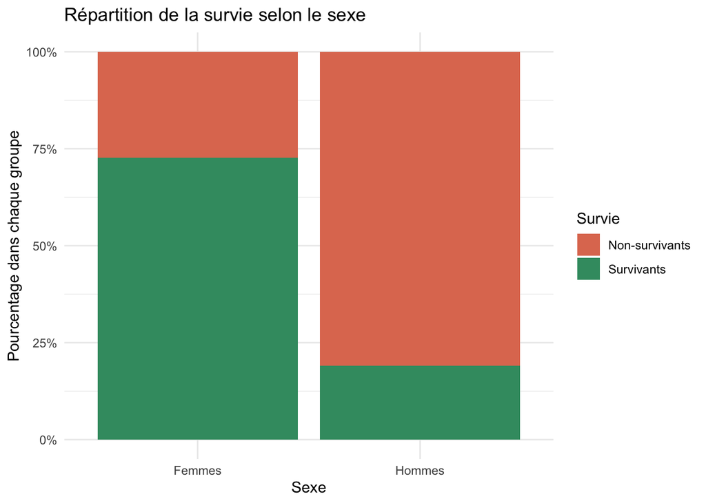

```r
library(ggplot2)

ggplot(TitanicSurvival, aes(x = sex, fill = survived)) +
  geom_bar(position = "fill") +
  scale_y_continuous(labels = function(x) paste0(x * 100, "%")) +
  scale_x_discrete(labels = c(female = "Femmes", male = "Hommes")) +
  scale_fill_manual(
    values = c(no = "#E07A5F", yes = "#3D9970"),
    labels = c(no = "Non-survivants", yes = "Survivants")
  ) +
  labs(
    title = "Répartition de la survie selon le sexe",
    x = "Sexe",
    y = "Pourcentage dans chaque groupe",
    fill = "Survie"
  ) +
  theme_minimal()
```

## Taux de survie selon le sexe

```r
round(
  100 * prop.table(
    table(TitanicSurvival$sex, TitanicSurvival$survived),
    margin = 1
  ),
  1
)
```

```
##
##            no  yes
##   female 27.3 72.7
##   male   80.9 19.1
```

## Interprétation

La proportion de survivants est plus élevée chez les femmes que chez les hommes. Les pourcentages sont calculés au sein de chaque sexe, ce qui permet de comparer les groupes malgré leurs effectifs différents. Cette comparaison décrit une association entre le sexe et la survie, sans tenir compte de l’âge ni de la classe des passagers.

# 4. Survie selon la classe

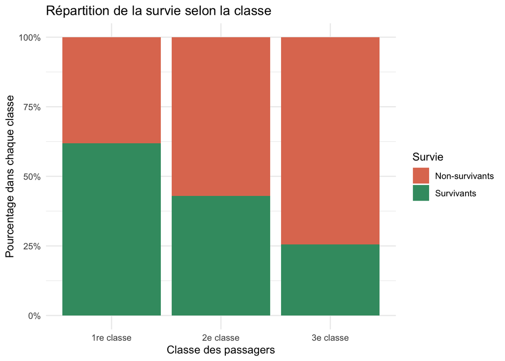

```r
ggplot(TitanicSurvival, aes(x = passengerClass, fill = survived)) +
  geom_bar(position = "fill") +
  scale_y_continuous(labels = function(x) paste0(x * 100, "%")) +
  scale_x_discrete(
    labels = c("1st" = "1re classe",
               "2nd" = "2e classe",
               "3rd" = "3e classe")
  ) +
  scale_fill_manual(
    values = c(no = "#E07A5F", yes = "#3D9970"),
    labels = c(no = "Non-survivants", yes = "Survivants")
  ) +
  labs(
    title = "Répartition de la survie selon la classe",
    x = "Classe des passagers",
    y = "Pourcentage dans chaque classe",
    fill = "Survie"
  ) +
  theme_minimal()
```

## Pourcentages de survie selon la classe

```r
round(
  100 * prop.table(
    table(TitanicSurvival$passengerClass, TitanicSurvival$survived),
    margin = 1
  ),
  1
)
```

```
##
##         no  yes
##   1st 38.1 61.9
##   2nd 57.0 43.0
##   3rd 74.5 25.5
```

## Interprétation

La proportion de survivants est la plus élevée en première classe, intermédiaire en deuxième classe et la plus faible en troisième classe. Les pourcentages sont calculés au sein de chaque classe. Cette comparaison décrit une association entre la classe et la survie, sans tenir compte des différences de sexe et d’âge entre les classes.

# 5. Âge selon la survie

Les 263 passagers dont l’âge est manquant sont exclus de cette analyse.

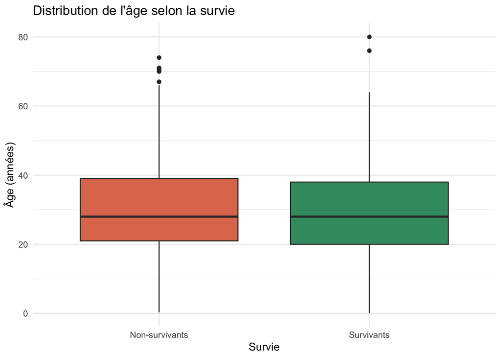

```r
donnees_age <- subset(TitanicSurvival, !is.na(age))

ggplot(donnees_age, aes(x = survived, y = age, fill = survived)) +
  geom_boxplot() +
  scale_x_discrete(
    labels = c(no = "Non-survivants", yes = "Survivants")
  ) +
  scale_fill_manual(
    values = c(no = "#E07A5F", yes = "#3D9970")
  ) +
  labs(
    title = "Distribution de l'âge selon la survie",
    x = "Survie",
    y = "Âge (années)"
  ) +
  theme_minimal() +
  theme(legend.position = "none")
```

## Statistiques d’âge par groupe

```r
aggregate(
  age ~ survived,
  data = donnees_age,
  FUN = function(x) c(
    effectif = length(x),
    moyenne = mean(x),
    mediane = median(x),
    ecart_type = sd(x)
  )
)
```

```
##   survived age.effectif age.moyenne age.mediane age.ecart_type
## 1       no    619.00000    30.54537    28.00000       13.92254
## 2      yes    427.00000    28.91823    28.00000       15.06148
```

## Interprétation

Les boîtes à moustaches permettent de comparer la médiane et la dispersion des âges entre survivants et non-survivants. Le trait à l’intérieur de chaque boîte représente la médiane ; la boîte contient les 50 % centraux des âges.

Les distributions se chevauchent : l’âge seul ne permet donc pas de distinguer clairement les survivants des non-survivants. Cette analyse porte uniquement sur les passagers dont l’âge est connu. Les valeurs manquantes peuvent limiter la représentativité des résultats.

# 6. Utilisation du package TitanicPackage

```r
library(TitanicPackage)

taux_survie(TitanicSurvival, "sex")
```

```
##   groupe taux_survie_pct
## 1 female            72.7
## 2   male            19.1
```

```r
taux_survie(TitanicSurvival, "passengerClass")
```

```
##   groupe taux_survie_pct
## 1    1st            61.9
## 2    2nd            43.0
## 3    3rd            25.5
```

Le taux de survie est de 72,7 % chez les femmes et de 19,1 % chez les hommes. Il est de 61,9 % en première classe, 43,0 % en deuxième classe et 25,5 % en troisième classe.

Ces comparaisons sont descriptives : elles ne permettent pas d’isoler l’effet propre du sexe, de la classe ou de l’âge.